# RegressionTree-RandomForest

Nikola_Stankovic

## Regression Tree

Packages required to build and plot regression trees

```r
install.packages("rpart",repos = "http://cran.rstudio.com/")
library(rpart)
```

```r
install.packages("rpart.plot",repos = "http://cran.rstudio.com/")
library(rpart.plot)
```

Package used to perform cross-validation calls to ‘cross-validation-rt.R’ script

```r
install.packages("cvTools",repos = "http://cran.rstudio.com/")
library(cvTools)
```

### Import prepared data set from the Data Analysis step

```r
load("C:/CKME136/Forest Fires/fdata.RDa")
fdata <- fdatatemp
```

Keep log transformation of area (arealog) as the dependent variable, remove area

```r
fdata <- fdata[,c(5:17)]
fdata_rt <- fdata[,c(-9)]
```

### 1. Weather variable combination

I tried different number of minbuckets, and the minimum number of buckets = 8 produced the same results in the author’s paper

```r
sel_var <- "temp + RH + rain + wind"
nofbuckets <- 8 #default value for minbuckets
cp_value <- 0 # used for pruning
```

Validate tree using cross validation

```r
source('C:/CKME136/Forest Fires/FinalSubmission/cross-validation-arealog-rt.R', echo = TRUE)
```

```
##
## > set.seed(12)
##
## > k <- 10
##
## > R <- 30
##
## > folds <- cvFolds(nrow(fdata_rt), K = k, R = R)
##
## > pred_matrix <- matrix(rep(0, R * nrow(fdata_rt)),
## +     nrow(fdata_rt), R, byrow = T)
##
## > predictions <- data.frame(pred_matrix)
##
## > predictions$arealog <- fdata_rt$arealog
##
## > for (j in 1:R) {
## +     for (i in 1:k) {
## +         train <- fdata_rt[folds$subsets[folds$which != i, j],
## +             ]
## +         validation <- fda .... [TRUNCATED]
##
## > sum_abs = 0
##
## > sum_squares = 0
##
## > for (m in 1:R) {
## +     sum_abs = sum_abs + (abs((2.718268237^predictions[, R + 1] -
## +         1) - (2.718268237^predictions[, m] - 1)))
## +     sum_s .... [TRUNCATED]
##
## > RMSE = sqrt(mean(sum_squares/R))
##
## > MAD = mean(sum_abs/R)
##
## > RMSE
## [1] 64.49935
##
## > MAD
## [1] 13.15522
```

##### > RMSE

##### [1] 64.49935

##### > MAD

##### [1] 13.15522

The cross validation results using 8 as the minimum number of observations in a terminal leaf are in line with the paper (RMSE 64.4 and MAD 13.18)

Visual representation of the tree using entire dataset:

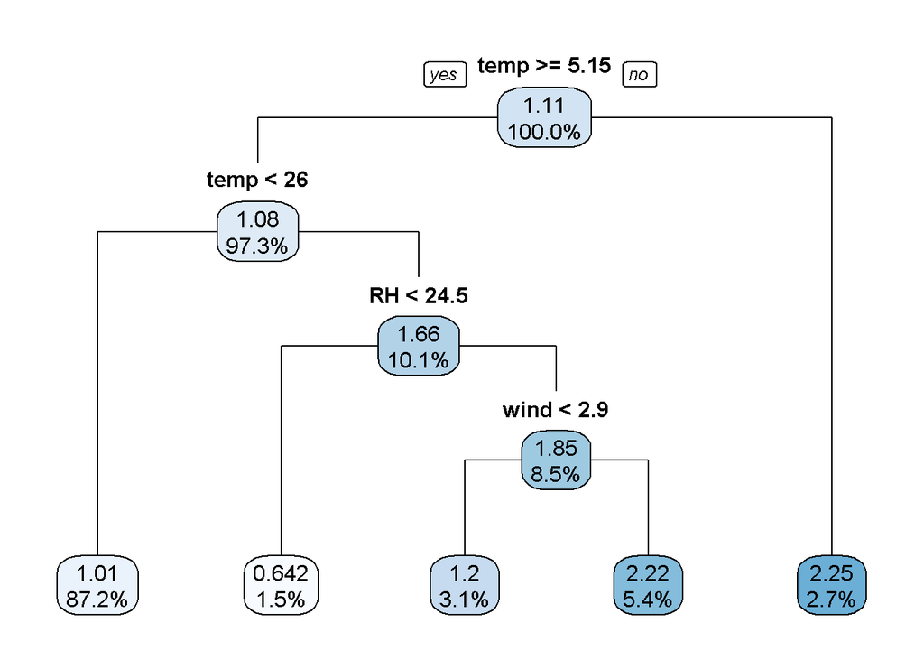

```r
rt.w <- (rpart(as.formula(paste("arealog ~", sel_var)), method = "anova",
                   data = fdata_rt, control = rpart.control(minbucket = nofbuckets)))
rpart.plot(rt.w, type =1, digit=3, fallen.leaves = TRUE)
```

```r
summary(rt.w)
```

```
## Call:
## rpart(formula = as.formula(paste("arealog ~", sel_var)), data = fdata_rt,
##     method = "anova", control = rpart.control(minbucket = nofbuckets))
##   n= 517
##
##           CP nsplit rel error   xerror       xstd
## 1 0.01903771      0 1.0000000 1.003844 0.07556031
## 2 0.01007513      2 0.9619246 1.013703 0.07949907
## 3 0.01000000      4 0.9417743 1.051576 0.08141551
##
## Variable importance
## temp wind   RH
##   66   18   17
##
## Node number 1: 517 observations,    complexity param=0.01903771
##   mean=1.111026, MSE=1.95184
##   left son=2 (503 obs) right son=3 (14 obs)
##   Primary splits:
##       temp < 5.15  to the right, improve=0.018496620, (0 missing)
##       wind < 8.25  to the left,  improve=0.011491950, (0 missing)
##       RH   < 71.5  to the right, improve=0.007123461, (0 missing)
##       rain < 0.1   to the right, improve=0.003487323, (0 missing)
##
## Node number 2: 503 observations,    complexity param=0.01903771
##   mean=1.079327, MSE=1.948944
##   left son=4 (451 obs) right son=5 (52 obs)
##   Primary splits:
##       temp < 26    to the left,  improve=0.020153650, (0 missing)
##       RH   < 71.5  to the right, improve=0.009649996, (0 missing)
##       wind < 5.15  to the right, improve=0.004514722, (0 missing)
##       rain < 0.1   to the right, improve=0.003253641, (0 missing)
##
## Node number 3: 14 observations
##   mean=2.249933, MSE=0.7227123
##
## Node number 4: 451 observations
##   mean=1.01203, MSE=1.814926
##
## Node number 5: 52 observations,    complexity param=0.01007513
##   mean=1.662991, MSE=2.731343
```

[output cut: 9 more lines]

```
## Node number 11: 44 observations,    complexity param=0.01007513
##   mean=1.848626, MSE=2.610506
##   left son=22 (16 obs) right son=23 (28 obs)
##   Primary splits:
##       wind < 2.9   to the left,  improve=0.09122222, (0 missing)
##       RH   < 29.5  to the right, improve=0.04745598, (0 missing)
##       temp < 27.55 to the right, improve=0.03918345, (0 missing)
##   Surrogate splits:
##       temp < 31.65 to the right, agree=0.659, adj=0.062, (0 split)
##
## Node number 22: 16 observations
##   mean=1.203073, MSE=1.244374
##
## Node number 23: 28 observations
##   mean=2.217513, MSE=3.01694
```

Variable importance temp 66 wind 18 RH 17

```r
printcp(rt.w)
```

```
##
## Regression tree:
## rpart(formula = as.formula(paste("arealog ~", sel_var)), data = fdata_rt,
##     method = "anova", control = rpart.control(minbucket = nofbuckets))
##
## Variables actually used in tree construction:
## [1] RH   temp wind
##
## Root node error: 1009.1/517 = 1.9518
##
## n= 517
##
##         CP nsplit rel error xerror     xstd
## 1 0.019038      0   1.00000 1.0038 0.075560
## 2 0.010075      2   0.96192 1.0137 0.079499
## 3 0.010000      4   0.94177 1.0516 0.081416
```

The CP table above shows that nsplit = 0 is the best model This means the average of the entire dataset will always be used for any future predicitons This is not a good prediction

The code below is shown how prunining is doNe in rpart package, however I will not use the prunned tree for any reference

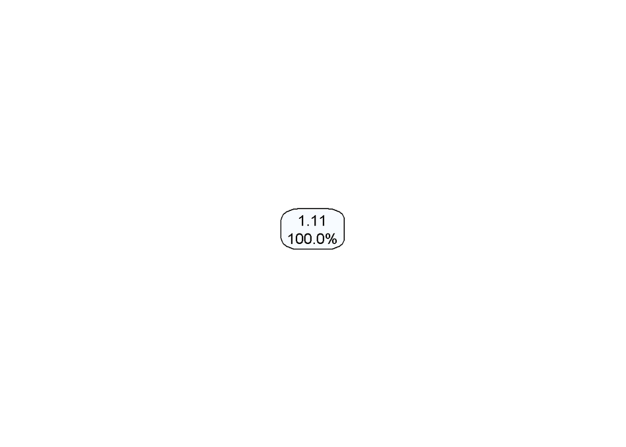

```r
bestcp <- rt.w$cptable[which.min(rt.w$cptable[,"xerror"]),"CP"]
rt.w.pruned <- prune(rt.w, cp = bestcp)
rpart.plot(rt.w.pruned, type =1, digit=3, fallen.leaves = TRUE)
```

### 2 decision tree model using all predictors with minbuckets of 29

```r
sel_var <- "."
nofbuckets <- 29 #
cp_value <- 0
```

visual representation of the tree

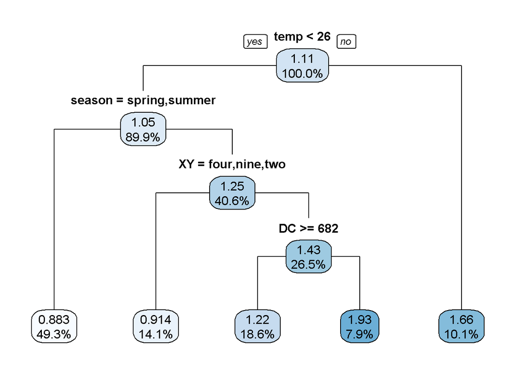

```r
rt.all <- (rpart(as.formula(paste("arealog ~", sel_var)), method = "anova",
                    data = fdata_rt, control = rpart.control(minbucket = nofbuckets)))
rpart.plot(rt.all, type =1, digit=3, fallen.leaves = TRUE)
```

Validate the tree using cross validation

```r
source('C:/CKME136/Forest Fires/FinalSubmission/cross-validation-arealog-rt.R', echo = TRUE)
```

```
##
## > set.seed(12)
##
## > k <- 10
##
## > R <- 30
##
## > folds <- cvFolds(nrow(fdata_rt), K = k, R = R)
##
## > pred_matrix <- matrix(rep(0, R * nrow(fdata_rt)),
## +     nrow(fdata_rt), R, byrow = T)
##
## > predictions <- data.frame(pred_matrix)
##
## > predictions$arealog <- fdata_rt$arealog
##
## > for (j in 1:R) {
## +     for (i in 1:k) {
## +         train <- fdata_rt[folds$subsets[folds$which != i, j],
## +             ]
## +         validation <- fda .... [TRUNCATED]
##
## > sum_abs = 0
##
## > sum_squares = 0
##
## > for (m in 1:R) {
## +     sum_abs = sum_abs + (abs((2.718268237^predictions[, R + 1] -
## +         1) - (2.718268237^predictions[, m] - 1)))
## +     sum_s .... [TRUNCATED]
##
## > RMSE = sqrt(mean(sum_squares/R))
##
## > MAD = mean(sum_abs/R)
##
## > RMSE
## [1] 64.391
##
## > MAD
## [1] 13.08937
```

##### > RMSE

##### [1] 64.391

##### > MAD

##### [1] 13.08937

```r
printcp(rt.all)
```

```
##
## Regression tree:
## rpart(formula = as.formula(paste("arealog ~", sel_var)), data = fdata_rt,
##     method = "anova", control = rpart.control(minbucket = nofbuckets))
##
## Variables actually used in tree construction:
## [1] DC     season temp   XY
##
## Root node error: 1009.1/517 = 1.9518
##
## n= 517
##
##         CP nsplit rel error xerror     xstd
## 1 0.017455      0   1.00000 1.0057 0.075690
## 2 0.015491      1   0.98254 1.0555 0.079794
## 3 0.013630      2   0.96705 1.0635 0.080275
## 4 0.010000      4   0.93979 1.0574 0.080203
```

## Random Forest

Random Forest regression package

```r
install.packages("randomForest",repos = "http://cran.rstudio.com/")
library(randomForest)
# Package used to perform cross-validation calls to 'cross-validation-rt.R' script
install.packages("cvTools",repos = "http://cran.rstudio.com/")
library(cvTools)
```

Keep log transformation of area (arealog) as the dependent variable, remove area:

```r
fdata <- fdatatemp
fdata <- fdata[,c(5:17)]
fdata_rf <- fdata[,c(-9)]
```

1 - Weather model

```r
sel_var_rf <- "temp + RH + rain + wind"
nooftrees <- 100
```

Execute cross validation

```r
source('C:/CKME136/Forest Fires/FinalSubmission/cross-validation-arealog-rf.R', echo = TRUE)
```

```
##
## > max.deparse.length = 1000
##
## > set.seed(123)
##
## > k <- 10
##
## > R <- 30
##
## > folds <- cvFolds(nrow(fdata_rf), K = k, R = R)
##
## > pred_matrix <- matrix(rep(0, R * nrow(fdata_rf)),
## +     nrow(fdata_rf), R, byrow = T)
##
## > predictions <- data.frame(pred_matrix)
##
## > predictions$arealog <- fdata_rf$arealog
##
## > for (j in 1:R) {
## +     for (i in 1:k) {
## +         train <- fdata_rf[folds$subsets[folds$which != i, j],
## +             ]
## +         validation <- fda .... [TRUNCATED]
##
## > sum_abs = 0
##
## > sum_squares = 0
##
## > for (m in 1:R) {
## +     sum_abs = sum_abs + (abs((2.718268237^predictions[, R + 1] -
## +         1) - (2.718268237^predictions[, m] - 1)))
## +     sum_s .... [TRUNCATED]
##
## > RMSE = sqrt(mean(sum_squares/R))
##
## > MAD = mean(sum_abs/R)
##
## > RMSE
## [1] 64.43702
##
## > MAD
## [1] 12.93335
```

100 trees - thsi is in line with the paper (RMSE 64.4 and MAD 12.93)

##### > RMSE

##### [1] 64.43702

##### > MAD

##### [1] 12.93335

2 - all predictors

```r
sel_var_rf <- "."
nooftrees <- 100
```

Execute cross validation

```r
source('C:/CKME136/Forest Fires/FinalSubmission/cross-validation-arealog-rf.R', echo = TRUE)
```

```
##
## > max.deparse.length = 1000
##
## > set.seed(123)
##
## > k <- 10
##
## > R <- 30
##
## > folds <- cvFolds(nrow(fdata_rf), K = k, R = R)
##
## > pred_matrix <- matrix(rep(0, R * nrow(fdata_rf)),
## +     nrow(fdata_rf), R, byrow = T)
##
## > predictions <- data.frame(pred_matrix)
##
## > predictions$arealog <- fdata_rf$arealog
##
## > for (j in 1:R) {
## +     for (i in 1:k) {
## +         train <- fdata_rf[folds$subsets[folds$which != i, j],
## +             ]
## +         validation <- fda .... [TRUNCATED]
##
## > sum_abs = 0
##
## > sum_squares = 0
##
## > for (m in 1:R) {
## +     sum_abs = sum_abs + (abs((2.718268237^predictions[, R + 1] -
## +         1) - (2.718268237^predictions[, m] - 1)))
## +     sum_s .... [TRUNCATED]
##
## > RMSE = sqrt(mean(sum_squares/R))
##
## > MAD = mean(sum_abs/R)
##
## > RMSE
## [1] 64.38877
##
## > MAD
## [1] 13.16288
```

##### > RMSE

##### [1] 64.38877

##### > MAD

##### [1] 13.16288